# Twitter US Airlines sentiment Analysis

**Business Problem :** Create a classification model which analyze the sentiment from twitter comments

**Dataset location :**[Kaggle](https://www.kaggle.com/crowdflower/twitter-airline-sentiment)

**Description from Kaggle :**

This data originally came from Crowdflower's Data for Everyone library.

As the original source says,

A sentiment analysis job about the problems of each major U.S. airline. Twitter data was scraped from February of 2015 and contributors were asked to first classify positive, negative, and neutral tweets, followed by categorizing negative reasons (such as "late flight" or "rude service").

The data we're providing on Kaggle is a slightly reformatted version of the original source. It includes both a CSV file and SQLite database. The code that does these transformations is available on GitHub

For example, it contains whether the sentiment of the tweets in this set was positive, neutral, or negative for six US airlines:

Lets get started, As this is the text classification NLP problem , we are going to solve this problem with Deep learning library called as Keras

```python
import tf.keras
import pandas as pd
import numpy as np
import re
import collections
import matplotlib.pyplot as plt
from pathlib import Path
from sklearn.model_selection import train_test_split
from nltk.corpus import stopwords
from tf.keras.preprocessing.text import Tokenizer
from tf.keras.preprocessing.sequence import pad_sequences
from tf.keras.utils.np_utils import to_categorical
from sklearn.preprocessing import LabelEncoder
from tf.keras import models
from tf.keras import layers
#from tensorflow.python import keras
import tf.keras
from tf.keras.initializers import Constant
from tf.keras.layers import LSTM
import pandas_profiling as pp
```

[output not shown]

## Load the dataset

```python
data = pd.read_csv('tweets.csv')
```

## Exploratory Data analysis

Overview

Dataset info

| Number of variables | 15 |
| --- | --- |
| Number of observations | 14640 |
| Total Missing (%) | 28.2% |
| Total size in memory | 1.7 MiB |
| Average record size in memory | 120.0 B |

Variables types

| Numeric | 4 |
| --- | --- |
| Categorical | 11 |
| Boolean | 0 |
| Date | 0 |
| Text (Unique) | 0 |
| Rejected | 0 |
| Unsupported | 0 |

Warnings

- `airline_sentiment_gold` has 14600 / 99.7% missing values Missing

- `name` has a high cardinality: 7701 distinct values Warning

- `negativereason` has 5462 / 37.3% missing values Missing

- `negativereason_confidence` has 1344 / 9.2% zeros Zeros

- `negativereason_confidence` has 4118 / 28.1% missing values Missing

- `negativereason_gold` has 14608 / 99.8% missing values Missing

- `retweet_count` has 13873 / 94.8% zeros Zeros

- `retweet_count` is highly skewed (γ1 = 33.913) Skewed

- `text` has a high cardinality: 14427 distinct values Warning

- `tweet_coord` has 13621 / 93.0% missing values Missing

- `tweet_coord` has a high cardinality: 833 distinct values Warning

- `tweet_created` has a high cardinality: 14247 distinct values Warning

- `tweet_location` has 4733 / 32.3% missing values Missing

- `tweet_location` has a high cardinality: 3082 distinct values Warning

- `user_timezone` has 4820 / 32.9% missing values Missing

- `user_timezone` has a high cardinality: 86 distinct values Warning

- Dataset has 36 duplicate rows Warning

Variables

airline  
Categorical

| Distinct count | 6 |
| --- | --- |
| Unique (%) | 0.0% |
| Missing (%) | 0.0% |
| Missing (n) | 0 |

| United | 3822 |
| --- | --- |
| US Airways | 2913 |
| American | 2759 |
| Other values (3) | 5146 |

Toggle details

| Value | Count | Frequency (%) |  |
| --- | --- | --- | --- |
| United | 3822 | 26.1% |  |
| US Airways | 2913 | 19.9% |  |
| American | 2759 | 18.8% |  |
| Southwest | 2420 | 16.5% |  |
| Delta | 2222 | 15.2% |  |
| Virgin America | 504 | 3.4% |  |

airline_sentiment  
Categorical

| Distinct count | 3 |
| --- | --- |
| Unique (%) | 0.0% |
| Missing (%) | 0.0% |
| Missing (n) | 0 |

| negative | 9178 |
| --- | --- |
| neutral | 3099 |
| positive | 2363 |

Toggle details

| Value | Count | Frequency (%) |  |
| --- | --- | --- | --- |
| negative | 9178 | 62.7% |  |
| neutral | 3099 | 21.2% |  |
| positive | 2363 | 16.1% |  |

airline_sentiment_confidence  
Numeric

| Distinct count | 1023 |
| --- | --- |
| Unique (%) | 7.0% |
| Missing (%) | 0.0% |
| Missing (n) | 0 |
| Infinite (%) | 0.0% |
| Infinite (n) | 0 |

| Mean | 0.90017 |
| --- | --- |
| Minimum | 0.335 |
| Maximum | 1 |
| Zeros (%) | 0.0% |

Toggle details

**Statistics**

Quantile statistics

| Minimum | 0.335 |
| --- | --- |
| 5-th percentile | 0.6444 |
| Q1 | 0.6923 |
| Median | 1 |
| Q3 | 1 |
| 95-th percentile | 1 |
| Maximum | 1 |
| Range | 0.665 |
| Interquartile range | 0.3077 |

Descriptive statistics

| Standard deviation | 0.16283 |
| --- | --- |
| Coef of variation | 0.18089 |
| Kurtosis | 0.29822 |
| Mean | 0.90017 |
| MAD | 0.14252 |
| Skewness | -1.2393 |
| Sum | 13178 |
| Variance | 0.026514 |
| Memory size | 114.5 KiB |

**Histogram**

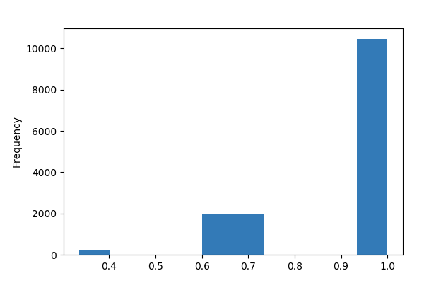

**Common Values**

| Value | Count | Frequency (%) |  |
| --- | --- | --- | --- |
| 1.0 | 10445 | 71.3% |  |
| 0.6667 | 71 | 0.5% |  |
| 0.6632 | 35 | 0.2% |  |
| 0.6559 | 30 | 0.2% |  |
| 0.6596 | 30 | 0.2% |  |
| 0.6701 | 29 | 0.2% |  |
| 0.6598 | 28 | 0.2% |  |
| 0.66 | 26 | 0.2% |  |
| 0.6842 | 26 | 0.2% |  |
| 0.6771 | 24 | 0.2% |  |
| Other values (1013) | 3896 | 26.6% |  |

**Extreme Values**

Minimum 5 values

| Value | Count | Frequency (%) |  |
| --- | --- | --- | --- |
| 0.335 | 1 | 0.0% |  |
| 0.3353 | 1 | 0.0% |  |
| 0.3356 | 1 | 0.0% |  |
| 0.3363 | 1 | 0.0% |  |
| 0.3366 | 1 | 0.0% |  |

Maximum 5 values

| Value | Count | Frequency (%) |  |
| --- | --- | --- | --- |
| 0.9633 | 1 | 0.0% |  |
| 0.9657 | 1 | 0.0% |  |
| 0.9658 | 1 | 0.0% |  |
| 0.967 | 1 | 0.0% |  |
| 1.0 | 10445 | 71.3% |  |

airline_sentiment_gold  
Categorical

| Distinct count | 4 |
| --- | --- |
| Unique (%) | 0.0% |
| Missing (%) | 99.7% |
| Missing (n) | 14600 |

| negative | 32 |
| --- | --- |
| positive | 5 |
| neutral | 3 |
| (Missing) | 14600 |

Toggle details

| Value | Count | Frequency (%) |  |
| --- | --- | --- | --- |
| negative | 32 | 0.2% |  |
| positive | 5 | 0.0% |  |
| neutral | 3 | 0.0% |  |
| (Missing) | 14600 | 99.7% |  |

name  
Categorical

| Distinct count | 7701 |
| --- | --- |
| Unique (%) | 52.6% |
| Missing (%) | 0.0% |
| Missing (n) | 0 |

| JetBlueNews | 63 |
| --- | --- |
| kbosspotter | 32 |
| _mhertz | 29 |
| Other values (7698) | 14516 |

Toggle details

| Value | Count | Frequency (%) |  |
| --- | --- | --- | --- |
| JetBlueNews | 63 | 0.4% |  |
| kbosspotter | 32 | 0.2% |  |
| _mhertz | 29 | 0.2% |  |
| otisday | 28 | 0.2% |  |
| throthra | 27 | 0.2% |  |
| weezerandburnie | 23 | 0.2% |  |
| rossj987 | 23 | 0.2% |  |
| GREATNESSEOA | 22 | 0.2% |  |
| MeeestarCoke | 22 | 0.2% |  |
| scoobydoo9749 | 21 | 0.1% |  |
| Other values (7691) | 14350 | 98.0% |  |

negativereason  
Categorical

| Distinct count | 11 |
| --- | --- |
| Unique (%) | 0.1% |
| Missing (%) | 37.3% |
| Missing (n) | 5462 |

| Customer Service Issue | 2910 |
| --- | --- |
| Late Flight | 1665 |
| Can't Tell | 1190 |
| Other values (7) | 3413 |
| (Missing) | 5462 |

Toggle details

| Value | Count | Frequency (%) |  |
| --- | --- | --- | --- |
| Customer Service Issue | 2910 | 19.9% |  |
| Late Flight | 1665 | 11.4% |  |
| Can't Tell | 1190 | 8.1% |  |
| Cancelled Flight | 847 | 5.8% |  |
| Lost Luggage | 724 | 4.9% |  |
| Bad Flight | 580 | 4.0% |  |
| Flight Booking Problems | 529 | 3.6% |  |
| Flight Attendant Complaints | 481 | 3.3% |  |
| longlines | 178 | 1.2% |  |
| Damaged Luggage | 74 | 0.5% |  |
| (Missing) | 5462 | 37.3% |  |

negativereason_confidence  
Numeric

| Distinct count | 1411 |
| --- | --- |
| Unique (%) | 9.6% |
| Missing (%) | 28.1% |
| Missing (n) | 4118 |
| Infinite (%) | 0.0% |
| Infinite (n) | 0 |

| Mean | 0.6383 |
| --- | --- |
| Minimum | 0 |
| Maximum | 1 |
| Zeros (%) | 9.2% |

Toggle details

**Statistics**

Quantile statistics

| Minimum | 0 |
| --- | --- |
| 5-th percentile | 0 |
| Q1 | 0.3606 |
| Median | 0.6706 |
| Q3 | 1 |
| 95-th percentile | 1 |
| Maximum | 1 |
| Range | 1 |
| Interquartile range | 0.6394 |

Descriptive statistics

| Standard deviation | 0.33044 |
| --- | --- |
| Coef of variation | 0.51769 |
| Kurtosis | -0.65587 |
| Mean | 0.6383 |
| MAD | 0.26028 |
| Skewness | -0.60112 |
| Sum | 6716.2 |
| Variance | 0.10919 |
| Memory size | 114.5 KiB |

**Histogram**

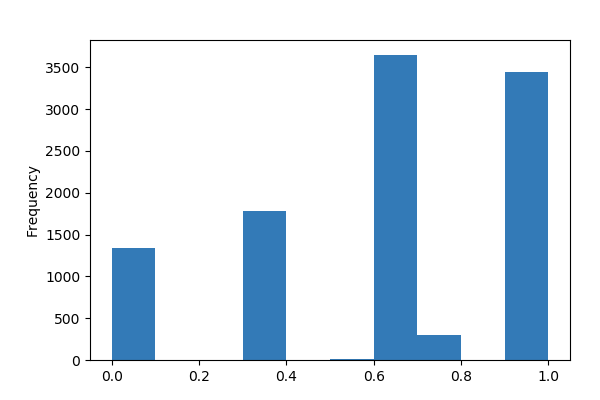

**Common Values**

| Value | Count | Frequency (%) |  |
| --- | --- | --- | --- |
| 1.0 | 3436 | 23.5% |  |
| 0.0 | 1344 | 9.2% |  |
| 0.6667 | 62 | 0.4% |  |
| 0.6632 | 33 | 0.2% |  |
| 0.6596 | 29 | 0.2% |  |
| 0.6733 | 25 | 0.2% |  |
| 0.6809 | 25 | 0.2% |  |
| 0.3441 | 24 | 0.2% |  |
| 0.6559 | 24 | 0.2% |  |
| 0.6701 | 23 | 0.2% |  |
| Other values (1400) | 5497 | 37.5% |  |
| (Missing) | 4118 | 28.1% |  |

**Extreme Values**

Minimum 5 values

| Value | Count | Frequency (%) |  |
| --- | --- | --- | --- |
| 0.0 | 1344 | 9.2% |  |
| 0.3122 | 1 | 0.0% |  |
| 0.3125 | 1 | 0.0% |  |
| 0.3146 | 1 | 0.0% |  |
| 0.3152 | 1 | 0.0% |  |

Maximum 5 values

| Value | Count | Frequency (%) |  |
| --- | --- | --- | --- |
| 0.9303 | 1 | 0.0% |  |
| 0.9553 | 1 | 0.0% |  |
| 0.9594 | 1 | 0.0% |  |
| 0.962 | 1 | 0.0% |  |
| 1.0 | 3436 | 23.5% |  |

negativereason_gold  
Categorical

| Distinct count | 14 |
| --- | --- |
| Unique (%) | 0.1% |
| Missing (%) | 99.8% |
| Missing (n) | 14608 |

| Customer Service Issue | 12 |
| --- | --- |
| Late Flight | 4 |
| Can't Tell | 3 |
| Other values (10) | 13 |
| (Missing) | 14608 |

Toggle details

| Value | Count | Frequency (%) |  |
| --- | --- | --- | --- |
| Customer Service Issue | 12 | 0.1% |  |
| Late Flight | 4 | 0.0% |  |
| Can't Tell | 3 | 0.0% |  |
| Cancelled Flight | 3 | 0.0% |  |
| Cancelled Flight Customer Service Issue | 2 | 0.0% |  |
| Flight Attendant Complaints | 1 | 0.0% |  |
| Late Flight Lost Luggage | 1 | 0.0% |  |
| Lost Luggage Damaged Luggage | 1 | 0.0% |  |
| Customer Service Issue Lost Luggage | 1 | 0.0% |  |
| Bad Flight | 1 | 0.0% |  |
| Other values (3) | 3 | 0.0% |  |
| (Missing) | 14608 | 99.8% |  |

retweet_count  
Numeric

| Distinct count | 18 |
| --- | --- |
| Unique (%) | 0.1% |
| Missing (%) | 0.0% |
| Missing (n) | 0 |
| Infinite (%) | 0.0% |
| Infinite (n) | 0 |

| Mean | 0.08265 |
| --- | --- |
| Minimum | 0 |
| Maximum | 44 |
| Zeros (%) | 94.8% |

Toggle details

**Statistics**

Quantile statistics

| Minimum | 0 |
| --- | --- |
| 5-th percentile | 0 |
| Q1 | 0 |
| Median | 0 |
| Q3 | 0 |
| 95-th percentile | 1 |
| Maximum | 44 |
| Range | 44 |
| Interquartile range | 0 |

Descriptive statistics

| Standard deviation | 0.74578 |
| --- | --- |
| Coef of variation | 9.0233 |
| Kurtosis | 1529.7 |
| Mean | 0.08265 |
| MAD | 0.15664 |
| Skewness | 33.913 |
| Sum | 1210 |
| Variance | 0.55619 |
| Memory size | 114.5 KiB |

**Histogram**

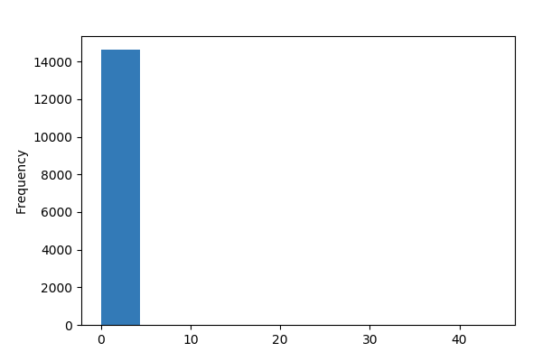

**Common Values**

| Value | Count | Frequency (%) |  |
| --- | --- | --- | --- |
| 0 | 13873 | 94.8% |  |
| 1 | 640 | 4.4% |  |
| 2 | 66 | 0.5% |  |
| 3 | 22 | 0.2% |  |
| 4 | 17 | 0.1% |  |
| 5 | 5 | 0.0% |  |
| 7 | 3 | 0.0% |  |
| 6 | 3 | 0.0% |  |
| 22 | 2 | 0.0% |  |
| 8 | 1 | 0.0% |  |
| Other values (8) | 8 | 0.1% |  |

**Extreme Values**

Minimum 5 values

| Value | Count | Frequency (%) |  |
| --- | --- | --- | --- |
| 0 | 13873 | 94.8% |  |
| 1 | 640 | 4.4% |  |
| 2 | 66 | 0.5% |  |
| 3 | 22 | 0.2% |  |
| 4 | 17 | 0.1% |  |

Maximum 5 values

| Value | Count | Frequency (%) |  |
| --- | --- | --- | --- |
| 22 | 2 | 0.0% |  |
| 28 | 1 | 0.0% |  |
| 31 | 1 | 0.0% |  |
| 32 | 1 | 0.0% |  |
| 44 | 1 | 0.0% |  |

text  
Categorical

| Distinct count | 14427 |
| --- | --- |
| Unique (%) | 98.5% |
| Missing (%) | 0.0% |
| Missing (n) | 0 |

| @united thanks | 6 |
| --- | --- |
| @SouthwestAir sent | 5 |
| @JetBlue thanks! | 5 |
| Other values (14424) | 14624 |

Toggle details

| Value | Count | Frequency (%) |  |
| --- | --- | --- | --- |
| @united thanks | 6 | 0.0% |  |
| @SouthwestAir sent | 5 | 0.0% |  |
| @JetBlue thanks! | 5 | 0.0% |  |
| @AmericanAir thanks | 5 | 0.0% |  |
| @united thank you! | 4 | 0.0% |  |
| @AmericanAir thank you! | 4 | 0.0% |  |
| @united Thanks! | 3 | 0.0% |  |
| @USAirways thanks | 3 | 0.0% |  |
| @SouthwestAir Thank you! | 3 | 0.0% |  |
| @USAirways thank you | 3 | 0.0% |  |
| Other values (14417) | 14599 | 99.7% |  |

tweet_coord  
Categorical

| Distinct count | 833 |
| --- | --- |
| Unique (%) | 5.7% |
| Missing (%) | 93.0% |
| Missing (n) | 13621 |

| [0.0, 0.0] | 164 |
| --- | --- |
| [40.64656067, -73.78334045] | 6 |
| [32.91792297, -97.00367737] | 3 |
| Other values (829) | 846 |
| (Missing) | 13621 |

Toggle details

| Value | Count | Frequency (%) |  |
| --- | --- | --- | --- |
| [0.0, 0.0] | 164 | 1.1% |  |
| [40.64656067, -73.78334045] | 6 | 0.0% |  |
| [32.91792297, -97.00367737] | 3 | 0.0% |  |
| [40.64646912, -73.79133606] | 3 | 0.0% |  |
| [39.1766101, -76.6700606] | 2 | 0.0% |  |
| [37.62006843, -122.38822083] | 2 | 0.0% |  |
| [40.69002464, -73.91638072] | 2 | 0.0% |  |
| [37.99311597, -84.52114659] | 2 | 0.0% |  |
| [33.75539049, -116.36196163] | 2 | 0.0% |  |
| [40.68994668, -73.91637642] | 2 | 0.0% |  |
| Other values (822) | 831 | 5.7% |  |
| (Missing) | 13621 | 93.0% |  |

tweet_created  
Categorical

| Distinct count | 14247 |
| --- | --- |
| Unique (%) | 97.3% |
| Missing (%) | 0.0% |
| Missing (n) | 0 |

| 2015-02-24 09:54:34 -0800 | 5 |
| --- | --- |
| 2015-02-24 11:43:05 -0800 | 4 |
| 2015-02-24 09:14:01 -0800 | 3 |
| Other values (14244) | 14628 |

Toggle details

| Value | Count | Frequency (%) |  |
| --- | --- | --- | --- |
| 2015-02-24 09:54:34 -0800 | 5 | 0.0% |  |
| 2015-02-24 11:43:05 -0800 | 4 | 0.0% |  |
| 2015-02-24 09:14:01 -0800 | 3 | 0.0% |  |
| 2015-02-24 11:38:47 -0800 | 3 | 0.0% |  |
| 2015-02-23 15:25:46 -0800 | 3 | 0.0% |  |
| 2015-02-24 11:38:11 -0800 | 3 | 0.0% |  |
| 2015-02-23 06:57:24 -0800 | 3 | 0.0% |  |
| 2015-02-23 14:18:58 -0800 | 3 | 0.0% |  |
| 2015-02-24 10:01:50 -0800 | 3 | 0.0% |  |
| 2015-02-24 11:32:49 -0800 | 3 | 0.0% |  |
| Other values (14237) | 14607 | 99.8% |  |

tweet_id  
Numeric

| Distinct count | 14485 |
| --- | --- |
| Unique (%) | 98.9% |
| Missing (%) | 0.0% |
| Missing (n) | 0 |
| Infinite (%) | 0.0% |
| Infinite (n) | 0 |

| Mean | 5.6922e+17 |
| --- | --- |
| Minimum | 567588278875213824 |
| Maximum | 570310600460525568 |
| Zeros (%) | 0.0% |

Toggle details

**Statistics**

Quantile statistics

| Minimum | 567588278875213824 |
| --- | --- |
| 5-th percentile | 5.6781e+17 |
| Q1 | 5.6856e+17 |
| Median | 5.6948e+17 |
| Q3 | 5.6989e+17 |
| 95-th percentile | 5.7026e+17 |
| Maximum | 570310600460525568 |
| Range | 2722321585311744 |
| Interquartile range | 1331300000000000 |

Descriptive statistics

| Standard deviation | 779110000000000 |
| --- | --- |
| Coef of variation | 0.0013687 |
| Kurtosis | -1.0488 |
| Mean | 5.6922e+17 |
| MAD | 676020000000000 |
| Skewness | -0.47512 |
| Sum | -4571651440528542603 |
| Variance | 6.0701e+29 |
| Memory size | 114.5 KiB |

**Histogram**

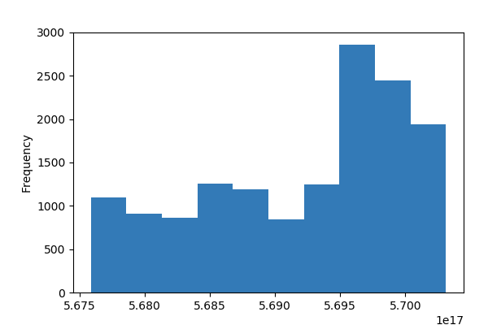

**Common Values**

| Value | Count | Frequency (%) |  |
| --- | --- | --- | --- |
| 570296616688750592 | 2 | 0.0% |  |
| 570273819287531520 | 2 | 0.0% |  |
| 570297548726005761 | 2 | 0.0% |  |
| 570275970046775297 | 2 | 0.0% |  |
| 570306867878072320 | 2 | 0.0% |  |
| 570284862122233856 | 2 | 0.0% |  |
| 570272172679282688 | 2 | 0.0% |  |
| 570307434113310720 | 2 | 0.0% |  |
| 570283851018317824 | 2 | 0.0% |  |
| 570307312675651585 | 2 | 0.0% |  |
| Other values (14475) | 14620 | 99.9% |  |

**Extreme Values**

Minimum 5 values

| Value | Count | Frequency (%) |  |
| --- | --- | --- | --- |
| 567588278875213824 | 1 | 0.0% |  |
| 567590027375702016 | 1 | 0.0% |  |
| 567591480085463040 | 1 | 0.0% |  |
| 567592368451248130 | 1 | 0.0% |  |
| 567594449874587648 | 1 | 0.0% |  |

Maximum 5 values

| Value | Count | Frequency (%) |  |
| --- | --- | --- | --- |
| 570309308937842688 | 1 | 0.0% |  |
| 570309340952993796 | 1 | 0.0% |  |
| 570309345281486848 | 1 | 0.0% |  |
| 570310144459972608 | 1 | 0.0% |  |
| 570310600460525568 | 1 | 0.0% |  |

tweet_location  
Categorical

| Distinct count | 3082 |
| --- | --- |
| Unique (%) | 21.1% |
| Missing (%) | 32.3% |
| Missing (n) | 4733 |

| Boston, MA | 157 |
| --- | --- |
| New York, NY | 156 |
| Washington, DC | 150 |
| Other values (3078) | 9444 |
| (Missing) | 4733 |

Toggle details

| Value | Count | Frequency (%) |  |
| --- | --- | --- | --- |
| Boston, MA | 157 | 1.1% |  |
| New York, NY | 156 | 1.1% |  |
| Washington, DC | 150 | 1.0% |  |
| New York | 127 | 0.9% |  |
| USA | 126 | 0.9% |  |
| Chicago | 104 | 0.7% |  |
| Los Angeles, CA | 96 | 0.7% |  |
| New York City | 96 | 0.7% |  |
| NYC | 95 | 0.6% |  |
| San Francisco, CA | 91 | 0.6% |  |
| Other values (3071) | 8709 | 59.5% |  |
| (Missing) | 4733 | 32.3% |  |

user_timezone  
Categorical

| Distinct count | 86 |
| --- | --- |
| Unique (%) | 0.6% |
| Missing (%) | 32.9% |
| Missing (n) | 4820 |

| Eastern Time (US & Canada) | 3744 |
| --- | --- |
| Central Time (US & Canada) | 1931 |
| Pacific Time (US & Canada) | 1208 |
| Other values (82) | 2937 |
| (Missing) | 4820 |

Toggle details

| Value | Count | Frequency (%) |  |
| --- | --- | --- | --- |
| Eastern Time (US & Canada) | 3744 | 25.6% |  |
| Central Time (US & Canada) | 1931 | 13.2% |  |
| Pacific Time (US & Canada) | 1208 | 8.3% |  |
| Quito | 738 | 5.0% |  |
| Atlantic Time (Canada) | 497 | 3.4% |  |
| Mountain Time (US & Canada) | 369 | 2.5% |  |
| Arizona | 229 | 1.6% |  |
| London | 195 | 1.3% |  |
| Alaska | 108 | 0.7% |  |
| Sydney | 107 | 0.7% |  |
| Other values (75) | 694 | 4.7% |  |
| (Missing) | 4820 | 32.9% |  |

Correlations

Sample

|  | tweet_id | airline_sentiment | airline_sentiment_confidence | negativereason | negativereason_confidence | airline | airline_sentiment_gold | name | negativereason_gold | retweet_count | text | tweet_coord | tweet_created | tweet_location | user_timezone |
| --- | --- | --- | --- | --- | --- | --- | --- | --- | --- | --- | --- | --- | --- | --- | --- |
| 0 | 570306133677760513 | neutral | 1.0000 | NaN | NaN | Virgin America | NaN | cairdin | NaN | 0 | @VirginAmerica What @dhepburn said. | NaN | 2015-02-24 11:35:52 -0800 | NaN | Eastern Time (US & Canada) |
| 1 | 570301130888122368 | positive | 0.3486 | NaN | 0.0000 | Virgin America | NaN | jnardino | NaN | 0 | @VirginAmerica plus you've added commercials t... | NaN | 2015-02-24 11:15:59 -0800 | NaN | Pacific Time (US & Canada) |
| 2 | 570301083672813571 | neutral | 0.6837 | NaN | NaN | Virgin America | NaN | yvonnalynn | NaN | 0 | @VirginAmerica I didn't today... Must mean I n... | NaN | 2015-02-24 11:15:48 -0800 | Lets Play | Central Time (US & Canada) |
| 3 | 570301031407624196 | negative | 1.0000 | Bad Flight | 0.7033 | Virgin America | NaN | jnardino | NaN | 0 | @VirginAmerica it's really aggressive to blast... | NaN | 2015-02-24 11:15:36 -0800 | NaN | Pacific Time (US & Canada) |
| 4 | 570300817074462722 | negative | 1.0000 | Can't Tell | 1.0000 | Virgin America | NaN | jnardino | NaN | 0 | @VirginAmerica and it's a really big bad thing... | NaN | 2015-02-24 11:14:45 -0800 | NaN | Pacific Time (US & Canada) |

```python
pp.ProfileReport(data)
```

```python
df = data[['text', 'airline_sentiment']]
```

```python
pp.ProfileReport(df)
```

Overview

Dataset info

| Number of variables | 2 |
| --- | --- |
| Number of observations | 14640 |
| Total Missing (%) | 0.0% |
| Total size in memory | 228.8 KiB |
| Average record size in memory | 16.0 B |

Variables types

| Numeric | 0 |
| --- | --- |
| Categorical | 2 |
| Boolean | 0 |
| Date | 0 |
| Text (Unique) | 0 |
| Rejected | 0 |
| Unsupported | 0 |

Warnings

- `text` has a high cardinality: 14427 distinct values Warning

- Dataset has 188 duplicate rows Warning

Variables

airline_sentiment  
Categorical

| Distinct count | 3 |
| --- | --- |
| Unique (%) | 0.0% |
| Missing (%) | 0.0% |
| Missing (n) | 0 |

| negative | 9178 |
| --- | --- |
| neutral | 3099 |
| positive | 2363 |

Toggle details

| Value | Count | Frequency (%) |  |
| --- | --- | --- | --- |
| negative | 9178 | 62.7% |  |
| neutral | 3099 | 21.2% |  |
| positive | 2363 | 16.1% |  |

text  
Categorical

| Distinct count | 14427 |
| --- | --- |
| Unique (%) | 98.5% |
| Missing (%) | 0.0% |
| Missing (n) | 0 |

| @united thanks | 6 |
| --- | --- |
| @SouthwestAir sent | 5 |
| @JetBlue thanks! | 5 |
| Other values (14424) | 14624 |

Toggle details

| Value | Count | Frequency (%) |  |
| --- | --- | --- | --- |
| @united thanks | 6 | 0.0% |  |
| @SouthwestAir sent | 5 | 0.0% |  |
| @JetBlue thanks! | 5 | 0.0% |  |
| @AmericanAir thanks | 5 | 0.0% |  |
| @united thank you! | 4 | 0.0% |  |
| @AmericanAir thank you! | 4 | 0.0% |  |
| @united Thanks! | 3 | 0.0% |  |
| @USAirways thanks | 3 | 0.0% |  |
| @SouthwestAir Thank you! | 3 | 0.0% |  |
| @USAirways thank you | 3 | 0.0% |  |
| Other values (14417) | 14599 | 99.7% |  |

Correlations

Sample

|  | text | airline_sentiment |
| --- | --- | --- |
| 0 | @VirginAmerica What @dhepburn said. | neutral |
| 1 | @VirginAmerica plus you've added commercials t... | positive |
| 2 | @VirginAmerica I didn't today... Must mean I n... | neutral |
| 3 | @VirginAmerica it's really aggressive to blast... | negative |
| 4 | @VirginAmerica and it's a really big bad thing... | negative |

## dropping the duplicate data

```python
%time df.drop_duplicates(subset ="text",keep=False,inplace=True)
df.shape
```

```
Wall time: 98.5 ms
```

```
(14240, 2)
```

```python
df = df.reset_index(drop=True)
```

```python
x=data['text']
```

```python
import string
import re
def data_clean1(data):
    text  = "".join([char for char in data if char not in string.punctuation])
    text = re.sub('[0-9]+', '', text)
    text = re.sub(r'\s+', ' ', text)
    return text



from nltk.corpus import stopwords
def stopword(data):

    stopwordlist= stopwords.words('english')

    data = data.split()
    clean_data = [word for word in data if (word not in stopwordlist)]
    return " ".join(clean_data)


from textblob import Word
def lem_apply(data):

    data=data.split()
    new_data = [Word(word).lemmatize()  for word in data]
    return " ".join(new_data)
```

```python
%time df.text = df.text.apply(lambda x :data_clean1(x) )
%time df.text = df.text.apply(lambda x :stopword(x))
%time df.text = df.text.apply(lambda x :lem_apply(x))
```

## splitting of Dataset

```python
X_train, X_test, Y_train, Y_test = train_test_split(df.text, df.airline_sentiment, test_size=0.3, random_state=142)
```

## Tokinizing and data filtering with keras API

```python
size_words=11000
ks_tok = Tokenizer(num_words=size_words,filters='!"#$%&()*+,-./:;<=>?@[\\]^_`{|}~\t\n0123456789',lower=True,split=" ")
ks_tok.fit_on_texts(X_train)
```

## convering word to sequence of number

```python
X_train_seq = ks_tok.texts_to_sequences(X_train) # convert each sentence into number
X_test_seq = ks_tok.texts_to_sequences(X_test)

# also check fit_text_tokenizer, sequences_to_matrix, text_tokenizer, texts_to_matrix, texts_to_sequences_generator, texts_to_sequences
```

```python
max_count = X_train.apply(lambda x: len(x.split(' ')))
max_count.describe()
```

```
count    9968.000000
mean       11.689908
std         4.403139
min         2.000000
25%         8.000000
50%        12.000000
75%        15.000000
max        29.000000
Name: text, dtype: float64
```

## Padding with zero and making same lenght for each sequence of number

```python
X_train_seq_trunc = pad_sequences(X_train_seq, maxlen=28)
X_test_seq_trunc = pad_sequences(X_test_seq, maxlen=28)
```

```python
X_test_seq_trunc[1]
```

```
array([   0,    0,    0,    0,    0,    0,    0,    0,    0,    0,    0,
        460,    3,    2,  531, 3056,  278,   45,    2,   28,   32,  531,
        292,    1,  658,    8, 3056,  352])
```

## Label encoding of Target feature

```python
le = LabelEncoder()
y_train_le = le.fit_transform(Y_train)
y_test_le = le.transform(Y_test)
y_train_oh = to_categorical(y_train_le)
y_test_oh = to_categorical(y_test_le)
```

## Neural Network with Keras

```python
deep_inputs = layers.Input(shape=(28,))
embedding= layers.Embedding(11000 , 16 ,input_length=28 )(deep_inputs)
embedding = layers.Dropout(0.5)(embedding)
#embedding = layers.Dense(100, activation='sigmoid')(embedding)
embedding = layers.Flatten()(embedding)
embedding_out = layers.Dense(3, activation='softmax')(embedding)
deep_model = keras.Model(inputs=deep_inputs,outputs=embedding_out)
deep_model.compile(optimizer='rmsprop', loss='categorical_crossentropy', metrics=['accuracy'])
deep_model.summary()
```

```
_________________________________________________________________
Layer (type)                 Output Shape              Param #
=================================================================
input_33 (InputLayer)        (None, 28)                0
_________________________________________________________________
embedding_33 (Embedding)     (None, 28, 16)            176000
_________________________________________________________________
dropout_23 (Dropout)         (None, 28, 16)            0
_________________________________________________________________
flatten_21 (Flatten)         (None, 448)               0
_________________________________________________________________
dense_35 (Dense)             (None, 3)                 1347
=================================================================
Total params: 177,347
Trainable params: 177,347
Non-trainable params: 0
_________________________________________________________________
```

```python
deep_model.fit(X_train_seq_trunc,y_train_oh,epochs=100,batch_size=512)
```

```
<keras.callbacks.History at 0x21502402d68>
```

```python
result=deep_model.evaluate(X_train_seq_trunc,y_train_oh)
result
```

```
[0.03749603166298741, 0.9919743178170144]
```

```python
result=deep_model.evaluate(X_test_seq_trunc,y_test_oh)
result
```

```
[0.7948562879017677, 0.7668539325842697]
```

## Pretrained Glove

```python
### Glove embedding
GLOVE_DIM=100

glove_file = 'glove.twitter.27B.' + str(GLOVE_DIM) + 'd.txt'
emb_dict = {}
glove = open(glove_file,encoding="utf8")
for line in glove:
    values = line.split()
    word = values[0]
    vector = np.asarray(values[1:], dtype='float32')
    emb_dict[word] = vector
glove.close()
```

```python
emb_matrix=np.zeros((10000,100))
```

```python
for w,i in ks_tok.word_index.items():
    if i < 10000:
        vect = emb_dict.get(w)
        emb_matrix[i]= vect

    else:
        break
```

```python
nonzero_elements = np.count_nonzero(np.count_nonzero(emb_matrix, axis=1))
result=nonzero_elements / 10000
result
```

```
0.9999
```

## Neural network with Glove word embedding

```python
deep_inputs = layers.Input(shape=(28,),dtype='float32')
embedding= layers.Embedding(11000,100,embeddings_initializer=Constant(emb_matrix),input_length=28,trainable=True )(deep_inputs)
embedding = layers.Dropout(0.5)(embedding)
#embedding = layers.Dense(100, activation='sigmoid')(embedding)
embedding = layers.Flatten()(embedding)
embedding_out = layers.Dense(3)(embedding)
deep_model_glove = keras.Model(inputs=deep_inputs,outputs=embedding_out)
deep_model_glove.compile(optimizer='rmsprop', loss='categorical_crossentropy', metrics=['accuracy'])
deep_model_glove.summary()
```

```
_________________________________________________________________
Layer (type)                 Output Shape              Param #
=================================================================
input_24 (InputLayer)        (None, 28)                0
_________________________________________________________________
embedding_24 (Embedding)     (None, 28, 100)           1100000
_________________________________________________________________
dropout_18 (Dropout)         (None, 28, 100)           0
_________________________________________________________________
flatten_19 (Flatten)         (None, 2800)              0
_________________________________________________________________
dense_25 (Dense)             (None, 3)                 8403
=================================================================
Total params: 1,108,403
Trainable params: 1,108,403
Non-trainable params: 0
_________________________________________________________________
```

```python
deep_model_glove.fit(X_train_seq_trunc,y_train_oh,epochs=50,batch_size=128)
```

```
<keras.callbacks.History at 0x2149e216278>
```

## Deep learning with LSTM with Keras

```python
## LSTM
deep_inputs = layers.Input(shape=(28,))
embedding= layers.Embedding(11000 , 8 ,input_length=28 )(deep_inputs)
embedding = layers.LSTM(100,dropout=0.5, recurrent_dropout=0.5)(embedding)
embedding = layers.Dense(256, activation='sigmoid')(embedding)
embedding = layers.Dropout(0.5)(embedding)
#embedding = layers.Flatten()(embedding)
embedding_out = layers.Dense(3, activation='softmax')(embedding)
deep_model_lstm = keras.Model(inputs=deep_inputs,outputs=embedding_out)
deep_model_lstm.compile(optimizer='rmsprop', loss='categorical_crossentropy', metrics=['accuracy'])
deep_model_lstm.summary()
```

```
_________________________________________________________________
Layer (type)                 Output Shape              Param #
=================================================================
input_25 (InputLayer)        (None, 28)                0
_________________________________________________________________
embedding_25 (Embedding)     (None, 28, 8)             88000
_________________________________________________________________
lstm_4 (LSTM)                (None, 100)               43600
_________________________________________________________________
dense_26 (Dense)             (None, 256)               25856
_________________________________________________________________
dropout_19 (Dropout)         (None, 256)               0
_________________________________________________________________
dense_27 (Dense)             (None, 3)                 771
=================================================================
Total params: 158,227
Trainable params: 158,227
Non-trainable params: 0
_________________________________________________________________
```

```python
deep_model_lstm.fit(X_train_seq_trunc,y_train_oh,epochs=50,batch_size=512)
```

```
<keras.callbacks.History at 0x214b6d60550>
```

```python
result=deep_model_lstm.evaluate(X_train_seq_trunc,y_train_oh)
result
```

```
[0.21606208466555488, 0.9278691813804173]
```

```python
result=deep_model_lstm.evaluate(X_test_seq_trunc,y_test_oh)
result
```

```
[0.7101030747095743, 0.7734082397003745]
```

## Deep learning with stacked LSTM

```python
# LSTM multiple
deep_inputs = layers.Input(shape=(28,))
embedding= layers.Embedding(11000 , 8 ,input_length=28 )(deep_inputs)
embedding = layers.LSTM(256,dropout=0.5, recurrent_dropout=0.5,return_sequences = True)(embedding)
embedding = layers.LSTM(128,dropout=0.5, recurrent_dropout=0.5)(embedding)
#embedding = layers.Dense(256, activation='sigmoid')(embedding)
#embedding = layers.Dropout(0.5)(embedding)
#embedding = layers.Flatten()(embedding)
embedding_out = layers.Dense(3, activation='softmax')(embedding)
deep_model_lstm1 = keras.Model(inputs=deep_inputs,outputs=embedding_out)
deep_model_lstm1.compile(optimizer='rmsprop', loss='categorical_crossentropy', metrics=['accuracy'])
deep_model_lstm1.summary()
```

```
_________________________________________________________________
Layer (type)                 Output Shape              Param #
=================================================================
input_26 (InputLayer)        (None, 28)                0
_________________________________________________________________
embedding_26 (Embedding)     (None, 28, 8)             88000
_________________________________________________________________
lstm_5 (LSTM)                (None, 28, 256)           271360
_________________________________________________________________
lstm_6 (LSTM)                (None, 128)               197120
_________________________________________________________________
dense_28 (Dense)             (None, 3)                 387
=================================================================
Total params: 556,867
Trainable params: 556,867
Non-trainable params: 0
_________________________________________________________________
```

```python
deep_model_lstm1.fit(X_train_seq_trunc,y_train_oh,epochs=10,batch_size=512)
```

```
<keras.callbacks.History at 0x214b91a7550>
```

```python
result=deep_model_lstm1.evaluate(X_train_seq_trunc,y_train_oh)
result
```

```
[0.17049715037115312, 0.942215088282504]
```

```python
result=deep_model_lstm1.evaluate(X_test_seq_trunc,y_test_oh)
result
```

```
[0.7094433104500788, 0.7724719101123596]
```

## model building with CNN

```python
# CNN
deep_inputs = layers.Input(shape=(28,))
embedding= layers.Embedding(11000 , 8 ,input_length=28 )(deep_inputs)
embedding = layers.Conv1D(256, 5, activation='relu')(embedding)
embedding = layers.GlobalMaxPooling1D()(embedding)
#embedding = layers.Dense(128, activation='relu')(embedding)
embedding = layers.Dropout(0.5)(embedding)
#embedding = layers.Flatten()(embedding)
embedding_out = layers.Dense(3, activation='softmax')(embedding)
deep_model_lstm1 = keras.Model(inputs=deep_inputs,outputs=embedding_out)
deep_model_lstm1.compile(optimizer='rmsprop', loss='categorical_crossentropy', metrics=['accuracy'])
deep_model_lstm1.summary()
```

```
_________________________________________________________________
Layer (type)                 Output Shape              Param #
=================================================================
input_28 (InputLayer)        (None, 28)                0
_________________________________________________________________
embedding_28 (Embedding)     (None, 28, 8)             88000
_________________________________________________________________
conv1d_3 (Conv1D)            (None, 24, 256)           10496
_________________________________________________________________
global_max_pooling1d_3 (Glob (None, 256)               0
_________________________________________________________________
dropout_21 (Dropout)         (None, 256)               0
_________________________________________________________________
dense_30 (Dense)             (None, 3)                 771
=================================================================
Total params: 99,267
Trainable params: 99,267
Non-trainable params: 0
_________________________________________________________________
```

```python
deep_model_lstm1.fit(X_train_seq_trunc,y_train_oh,epochs=50,batch_size=512)
```

```
<keras.callbacks.History at 0x214b9815828>
```

```python
result=deep_model_lstm1.evaluate(X_test_seq_trunc,y_test_oh)
result
```

```
[1.2387185895934087, 0.7556179775280899]
```

```python
#CNN 2d
deep_inputs = layers.Input(shape=(28,))
embedding= layers.Embedding(11000 , 8 ,input_length=28 )(deep_inputs)
embedding = layers.Conv1D(256, 5,5, activation='relu')(embedding)
embedding = layers.GlobalMaxPooling1D()(embedding)
#embedding = layers.Dense(128, activation='relu')(embedding)
embedding = layers.Dropout(0.5)(embedding)
#embedding = layers.Flatten()(embedding)
embedding_out = layers.Dense(3, activation='softmax')(embedding)
deep_model_lstm1 = keras.Model(inputs=deep_inputs,outputs=embedding_out)
deep_model_lstm1.compile(optimizer='rmsprop', loss='categorical_crossentropy', metrics=['accuracy'])
deep_model_lstm1.summary()
```

[output not shown]

## Model building with GRU

```python
deep_inputs = layers.Input(shape=(28,))
embedding= layers.Embedding(11000 , 8 ,input_length=28 )(deep_inputs)
embedding = layers.GRU(100,dropout=0.5, recurrent_dropout=0.5)(embedding)
#embedding = layers.Dense(256, activation='sigmoid')(embedding)
#embedding = layers.Dropout(0.5)(embedding)
#embedding = layers.Flatten()(embedding)
embedding_out = layers.Dense(3, activation='softmax')(embedding)
deep_model_gru = keras.Model(inputs=deep_inputs,outputs=embedding_out)
deep_model_gru.compile(optimizer='rmsprop', loss='categorical_crossentropy', metrics=['accuracy'])
deep_model_gru.summary()
```

```
_________________________________________________________________
Layer (type)                 Output Shape              Param #
=================================================================
input_29 (InputLayer)        (None, 28)                0
_________________________________________________________________
embedding_29 (Embedding)     (None, 28, 8)             88000
_________________________________________________________________
gru_4 (GRU)                  (None, 100)               32700
_________________________________________________________________
dense_31 (Dense)             (None, 3)                 303
=================================================================
Total params: 121,003
Trainable params: 121,003
Non-trainable params: 0
_________________________________________________________________
```

```python
deep_model_gru.fit(X_train_seq_trunc,y_train_oh,epochs=50,batch_size=512)
```

```
<keras.callbacks.History at 0x214b996b1d0>
```

```python
result=deep_model_gru.evaluate(X_test_seq_trunc,y_test_oh)
result
```

```
[0.951221474435892, 0.7385299625468165]
```

## Model building with stacked GRU

```python
deep_inputs = layers.Input(shape=(28,))
embedding= layers.Embedding(11000 , 8 ,input_length=28 )(deep_inputs)
embedding = layers.GRU(100,dropout=0.5, recurrent_dropout=0.5,return_sequences = True)(embedding)
embedding = layers.GRU(100,dropout=0.5, recurrent_dropout=0.5)(embedding)
#embedding = layers.Dense(256, activation='sigmoid')(embedding)
#embedding = layers.Dropout(0.5)(embedding)
#embedding = layers.Flatten()(embedding)
embedding_out = layers.Dense(3, activation='softmax')(embedding)
deep_model_gru1 = keras.Model(inputs=deep_inputs,outputs=embedding_out)
deep_model_gru1.compile(optimizer='rmsprop', loss='categorical_crossentropy', metrics=['accuracy'])
deep_model_gru1.summary()
```

```
_________________________________________________________________
Layer (type)                 Output Shape              Param #
=================================================================
input_30 (InputLayer)        (None, 28)                0
_________________________________________________________________
embedding_30 (Embedding)     (None, 28, 8)             88000
_________________________________________________________________
gru_5 (GRU)                  (None, 28, 100)           32700
_________________________________________________________________
gru_6 (GRU)                  (None, 100)               60300
_________________________________________________________________
dense_32 (Dense)             (None, 3)                 303
=================================================================
Total params: 181,303
Trainable params: 181,303
Non-trainable params: 0
_________________________________________________________________
```

```python
deep_model_gru1.fit(X_train_seq_trunc,y_train_oh,epochs=50,batch_size=512)
```

```
<keras.callbacks.History at 0x214ff23e860>
```

```python
result=deep_model_gru1.evaluate(X_test_seq_trunc,y_test_oh)
result
```

```
[1.0604827667443493, 0.7324438202247191]
```

## Model building with bidirectional

```python
# Biderectional LSTM
deep_inputs = layers.Input(shape=(28,))
embedding= layers.Embedding(11000 , 8 ,input_length=28 )(deep_inputs)
embedding = layers.Bidirectional(LSTM(100,dropout=0.5, recurrent_dropout=0.5))(embedding)
#embedding = layers.Dense(256, activation='sigmoid')(embedding)
#embedding = layers.Dropout(0.5)(embedding)
#embedding = layers.Flatten()(embedding)
embedding_out = layers.Dense(3, activation='softmax')(embedding)
deep_model_bdir = keras.Model(inputs=deep_inputs,outputs=embedding_out)
deep_model_bdir.compile(optimizer='rmsprop', loss='categorical_crossentropy', metrics=['accuracy'])
deep_model_bdir.summary()
```

```
_________________________________________________________________
Layer (type)                 Output Shape              Param #
=================================================================
input_31 (InputLayer)        (None, 28)                0
_________________________________________________________________
embedding_31 (Embedding)     (None, 28, 8)             88000
_________________________________________________________________
bidirectional_1 (Bidirection (None, 200)               87200
_________________________________________________________________
dense_33 (Dense)             (None, 3)                 603
=================================================================
Total params: 175,803
Trainable params: 175,803
Non-trainable params: 0
_________________________________________________________________
```

```python
deep_model_bdir.fit(X_train_seq_trunc,y_train_oh,epochs=20,batch_size=512)
```

```
<keras.callbacks.History at 0x21509a1b588>
```

```python
result=deep_model_bdir.evaluate(X_test_seq_trunc,y_test_oh)
result
```

```
[1.2771495857488797, 0.7521067415730337]
```

## Hyperparameter optimization

#### Tuning model

```python
## NN , LSTM  hyperparameter tunning
from keras.wrappers.scikit_learn import KerasClassifier
from sklearn.model_selection import GridSearchCV
# Parameter Tunning
#param_grid = dict(num_filters=[32, 64, 128],kernel_size=[3, 5, 7],vocab_size=[vocab_size],embedding_dim=[embedding_dim],maxlen=[maxlen])


def NN_model():
    deep_inputs = layers.Input(shape=(28,))
    embedding= layers.Embedding(11000 , 16 ,input_length=28 )(deep_inputs)
    embedding = layers.Dropout(0.5)(embedding)
    #embedding = layers.Dense(100, activation='sigmoid')(embedding)
    embedding = layers.Flatten()(embedding)
    embedding_out = layers.Dense(3, activation='softmax')(embedding)
    deep_model = keras.Model(inputs=deep_inputs,outputs=embedding_out)
    deep_model.compile(optimizer='rmsprop', loss='categorical_crossentropy', metrics=['accuracy'])
    deep_model.summary()
    return deep_model

## Parameter to optimize
batch_size = [10, 20, 40, 60, 80, 100]
epochs = [10, 50, 100]
param_grid = dict(batch_size=batch_size, epochs=epochs)

model = KerasClassifier(build_fn=NN_model, verbose=0)
grid = GridSearchCV(estimator=model, param_grid=param_grid, n_jobs=-1)
grid_result = grid.fit(X_train_seq_trunc,y_train_oh)
# summarize results
print("Best: %f using %s" % (grid_result.best_score_, grid_result.best_params_))
means = grid_result.cv_results_['mean_test_score']
stds = grid_result.cv_results_['std_test_score']
params = grid_result.cv_results_['params']
for mean, stdev, param in zip(means, stds, params):
    print("%f (%f) with: %r" % (mean, stdev, param))
```

```
_________________________________________________________________
Layer (type)                 Output Shape              Param #
=================================================================
input_34 (InputLayer)        (None, 28)                0
_________________________________________________________________
embedding_34 (Embedding)     (None, 28, 16)            176000
_________________________________________________________________
dropout_24 (Dropout)         (None, 28, 16)            0
_________________________________________________________________
flatten_22 (Flatten)         (None, 448)               0
_________________________________________________________________
dense_36 (Dense)             (None, 3)                 1347
=================================================================
Total params: 177,347
Trainable params: 177,347
Non-trainable params: 0
_________________________________________________________________
Best: 0.773174 using {'batch_size': 100, 'epochs': 50}
0.765650 (0.008554) with: {'batch_size': 10, 'epochs': 10}
0.762339 (0.009410) with: {'batch_size': 10, 'epochs': 50}
0.756822 (0.007141) with: {'batch_size': 10, 'epochs': 100}
0.767255 (0.005524) with: {'batch_size': 20, 'epochs': 10}
0.764747 (0.005139) with: {'batch_size': 20, 'epochs': 50}
0.752709 (0.008361) with: {'batch_size': 20, 'epochs': 100}
0.772974 (0.006386) with: {'batch_size': 40, 'epochs': 10}
0.766653 (0.007930) with: {'batch_size': 40, 'epochs': 50}
0.754113 (0.007030) with: {'batch_size': 40, 'epochs': 100}
0.771770 (0.005369) with: {'batch_size': 60, 'epochs': 10}
0.768459 (0.009091) with: {'batch_size': 60, 'epochs': 50}
0.756722 (0.007163) with: {'batch_size': 60, 'epochs': 100}
0.767757 (0.006676) with: {'batch_size': 80, 'epochs': 10}
0.766653 (0.010457) with: {'batch_size': 80, 'epochs': 50}
0.761537 (0.007281) with: {'batch_size': 80, 'epochs': 100}
0.762741 (0.010257) with: {'batch_size': 100, 'epochs': 10}
0.773174 (0.007966) with: {'batch_size': 100, 'epochs': 50}
0.758026 (0.011030) with: {'batch_size': 100, 'epochs': 100}
```

```python
def NN_model1(optimizer='rmsprop'):
    deep_inputs = layers.Input(shape=(28,))
    embedding= layers.Embedding(11000 , 16 ,input_length=28 )(deep_inputs)
    embedding = layers.Dropout(0.5)(embedding)
    #embedding = layers.Dense(100, activation='sigmoid')(embedding)
    embedding = layers.Flatten()(embedding)
    embedding_out = layers.Dense(3, activation='softmax')(embedding)
    deep_model = keras.Model(inputs=deep_inputs,outputs=embedding_out)
    deep_model.compile(optimizer=optimizer, loss='categorical_crossentropy', metrics=['accuracy'])
    deep_model.summary()
    return deep_model

## Parameter to optimize
optimizer = ['SGD', 'RMSprop', 'Adagrad', 'Adadelta', 'Adam', 'Adamax', 'Nadam']
param_grid = dict(optimizer=optimizer,)

model = KerasClassifier(build_fn=NN_model1,batch_size=100,epochs=50, verbose=0)
grid = GridSearchCV(estimator=model, param_grid=param_grid, n_jobs=-1)
grid_result = grid.fit(X_train_seq_trunc,y_train_oh)
# summarize results
print("Best: %f using %s" % (grid_result.best_score_, grid_result.best_params_))
means = grid_result.cv_results_['mean_test_score']
stds = grid_result.cv_results_['std_test_score']
params = grid_result.cv_results_['params']
for mean, stdev, param in zip(means, stds, params):
    print("%f (%f) with: %r" % (mean, stdev, param))
```

```
_________________________________________________________________
Layer (type)                 Output Shape              Param #
=================================================================
input_35 (InputLayer)        (None, 28)                0
_________________________________________________________________
embedding_35 (Embedding)     (None, 28, 16)            176000
_________________________________________________________________
dropout_25 (Dropout)         (None, 28, 16)            0
_________________________________________________________________
flatten_23 (Flatten)         (None, 448)               0
_________________________________________________________________
dense_37 (Dense)             (None, 3)                 1347
=================================================================
Total params: 177,347
Trainable params: 177,347
Non-trainable params: 0
_________________________________________________________________
Best: 0.778090 using {'optimizer': 'Adamax'}
0.641051 (0.004515) with: {'optimizer': 'SGD'}
0.769964 (0.007804) with: {'optimizer': 'RMSprop'}
0.775682 (0.004808) with: {'optimizer': 'Adagrad'}
0.776786 (0.007887) with: {'optimizer': 'Adadelta'}
0.759530 (0.004644) with: {'optimizer': 'Adam'}
0.778090 (0.009503) with: {'optimizer': 'Adamax'}
0.744683 (0.012971) with: {'optimizer': 'Nadam'}
```

```python
def NN_model2(init_mode='uniform'):
    deep_inputs = layers.Input(shape=(28,))
    embedding= layers.Embedding(11000 , 16 ,embeddings_initializer=init_mode,input_length=28 )(deep_inputs)
    embedding = layers.Dropout(0.5)(embedding)
    #embedding = layers.Dense(100, activation='sigmoid')(embedding)
    embedding = layers.Flatten()(embedding)
    embedding_out = layers.Dense(3,kernel_initializer=init_mode, activation='softmax')(embedding)
    deep_model = keras.Model(inputs=deep_inputs,outputs=embedding_out)
    deep_model.compile(optimizer='Adamax', loss='categorical_crossentropy', metrics=['accuracy'])
    deep_model.summary()
    return deep_model

## Parameter to optimize
init_mode = ['uniform', 'lecun_uniform', 'normal', 'zero', 'glorot_normal', 'glorot_uniform', 'he_normal', 'he_uniform']
param_grid = dict(init_mode=init_mode,)

model = KerasClassifier(build_fn=NN_model2,batch_size=100,epochs=50, verbose=0)
grid = GridSearchCV(estimator=model, param_grid=param_grid, n_jobs=-1)
grid_result = grid.fit(X_train_seq_trunc,y_train_oh)
# summarize results
print("Best: %f using %s" % (grid_result.best_score_, grid_result.best_params_))
means = grid_result.cv_results_['mean_test_score']
stds = grid_result.cv_results_['std_test_score']
params = grid_result.cv_results_['params']
for mean, stdev, param in zip(means, stds, params):
    print("%f (%f) with: %r" % (mean, stdev, param))
```

```
_________________________________________________________________
Layer (type)                 Output Shape              Param #
=================================================================
input_37 (InputLayer)        (None, 28)                0
_________________________________________________________________
embedding_37 (Embedding)     (None, 28, 16)            176000
_________________________________________________________________
dropout_27 (Dropout)         (None, 28, 16)            0
_________________________________________________________________
flatten_25 (Flatten)         (None, 448)               0
_________________________________________________________________
dense_39 (Dense)             (None, 3)                 1347
=================================================================
Total params: 177,347
Trainable params: 177,347
Non-trainable params: 0
_________________________________________________________________
Best: 0.780899 using {'init_mode': 'normal'}
0.776986 (0.006669) with: {'init_mode': 'uniform'}
0.778792 (0.004921) with: {'init_mode': 'lecun_uniform'}
0.780899 (0.008453) with: {'init_mode': 'normal'}
0.632624 (0.007067) with: {'init_mode': 'zero'}
0.775281 (0.009818) with: {'init_mode': 'glorot_normal'}
0.778491 (0.003349) with: {'init_mode': 'glorot_uniform'}
0.776986 (0.006489) with: {'init_mode': 'he_normal'}
0.778090 (0.007485) with: {'init_mode': 'he_uniform'}
```